# Inference II

Stephen Blatti

August 4, 2017

# Monte Carlo

1. Imagine you are William_Sealy_Gosset and have just mathematically derived the distribution of the t-statistic when the sample comes from a normal distribution. Unlike Gosset you have access to computers and can use them to check the results.

Let’s start by creating an outcome.

Set the seed at 1, use rnorm to generate a random sample of size 5, $X_1,...,X_5$ from a standard normal distribution, then compute the t-statistic $t = {X}/s $ with s the sample standard deviation. What value do you observe?

```r
set.seed(1)
library(dplyr)
N <- 5
X <- rnorm(N)
X_bar <- mean(X)
s <- sd(X)
tstat <- sqrt(N)*X_bar / s
print(tstat)
```

```
## [1] 0.3007746
```

2. You have just performed a Monte Carlo simulation using rnorm, a random number generator for normally distributed data. Gosset’s mathematical calculation tells us that the t-statistic defined in the previous exercises, a random variable, follows a t-distribution with N - 1 degrees of freedom. Monte Carlo simulations can be used to check the theory: we generate many outcomes and compare them to the theoretical result. Set the seed to 1, generate B = 1000 t-statistics as done in exercise 1. What proportion is larger than 2?

```r
set.seed(1)

ttestGenerator <- function(n){
  X <- rnorm(n)
  tstat <- sqrt(n)*mean(X) / sd(X)
  return(tstat)
}
B = 1000
ttests <- replicate(B, ttestGenerator(5))
mean(ttests > 2)
```

```
## [1] 0.068
```

3. The answer to exercise 2 is very similar to the theoretical prediction: 1-pt(2,df=4). We can check several such quantiles using the qqplot function.

To obtain quantiles for the t-distribution we can generate percentiles from just above 0 to just below 1: B=100; ps = seq(1/(B+1), 1-1/(B+1),len=B) and compute the quantiles with qt(ps,df=4). Now we can use qqplot to compare these theoretical quantiles to those obtained in the Monte Carlo simulation. Use Monte Carlo simulation developed for exercise 2 to corroborate that the t-statistic t = sqrt(N) * X_bar / s follows a t-distribution for several values of N. For which sample sizes does the approximation best work?

Larger sample sizes. Smaller sample sizes. The approximations are spot on for all sample sizes. correct None. We should use CLT instead.

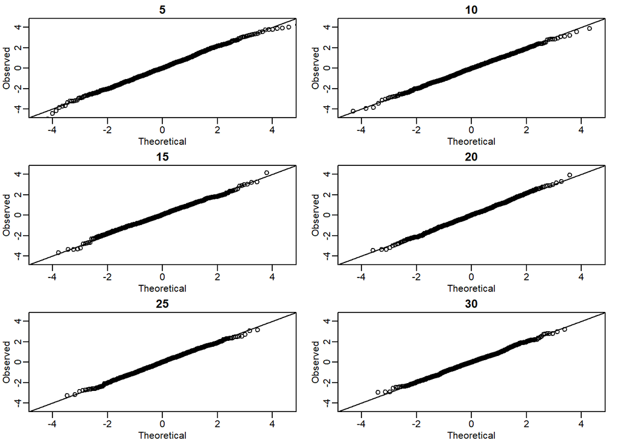

```r
set.seed(1)
# My soln one at a time
# ttestGenerator <- function(n){
#   X <- rnorm(n)
#   tstat <- sqrt(n)*mean(X) / sd(X)
#   return(tstat)
# }
# B <- 100
# ttests <- replicate(B, ttestGenerator(5)) # sample size 5
#
# ps <- seq(1 / (B + 1), 1 - 1/ (B + 1), len = B)
# qqplot(qt(ps, df = 4), ttests, xlim=c(-6,6),ylim=c(-6,6))
# abline(0,1)

# or
library(rafalib)
mypar(3,2)

Ns<-seq(5,30,5)
B <- 1000
mypar(3,2)
LIM <- c(-4.5,4.5)
for(N in Ns){
    ts <- replicate(B, {
    X <- rnorm(N)
    sqrt(N)*mean(X)/sd(X)
    })
    ps <- seq(1/(B+1),1-1/(B+1),len=B)
    qqplot(qt(ps,df=N-1),ts,main=N,
           xlab="Theoretical",ylab="Observed",
           xlim=LIM, ylim=LIM)
    abline(0,1)
}
```

4. Use Monte Carlo simulation to corroborate that the t-statistic comparing two means and obtained with normally distributed (mean 0 and sd) data follows a t-distribution. In this case we will use the t.test function with var.equal=TRUE. With this argument the degrees of freedom will be df=2*N-2 with N the sample size. For which sample sizes does the approximation best work?

Larger sample sizes. Smaller sample sizes. The approximations are spot on for all sample sizes. Correct None. We should use CLT instead.

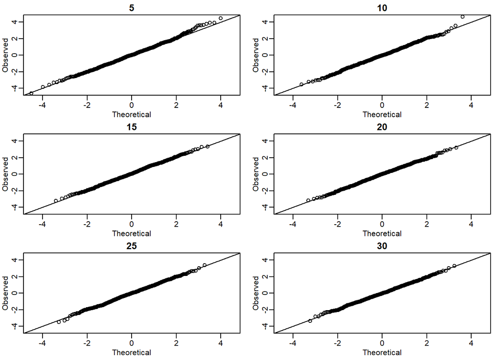

```r
Ns<-seq(5,30,5)
B <- 1000
mypar(3,2)
LIM <- c(-4.5,4.5)
for(N in Ns){
    ts <- replicate(B,{
    x <- rnorm(N)
    y <- rnorm(N)
    t.test(x,y, var.equal = TRUE)$stat
    })
  ps <- seq(1/(B+1),1-1/(B+1),len=B)
  qqplot(qt(ps,df=2*N-2),ts,main=N,
         xlab="Theoretical",ylab="Observed",
         xlim=LIM, ylim=LIM)
  abline(0,1)
}
```

5. Is the following statement true or false? If instead of generating the sample with X=rnorm(15) we generate it with binary data (either positive or negative 1 with probability 0.5) X =sample(c(-1,1), 15, replace=TRUE) then the t-statistic